# Analyzing Tooth Growth Data for Guinea Pigs

Tadashi Horie

# Overview

This is the second portion of the class, we’re going to analyze the ToothGrowth data in the R datasets package.

In this project, we are tasked these parts:

1. Load the ToothGrowth data and perform some basic exploratory data analyses
2. Provide a basic summary of the data.
3. Use confidence intervals and/or hypothesis tests to compare tooth growth by supp and dose. (Only use the techniques from class, even if there’s other approaches worth considering)
4. State your conclusions and the assumptions needed for your conclusions.

# Exercise

#### Loading add-on package

```r
library(ggplot2)
```

#### **1. Load the ToothGrowth data and perform some basic exploratory data analyses**

```r
data(ToothGrowth)  # ToothGrowth dataset
str(ToothGrowth)
```

```
## 'data.frame':    60 obs. of  3 variables:
##  $ len : num  4.2 11.5 7.3 5.8 6.4 10 11.2 11.2 5.2 7 ...
##  $ supp: Factor w/ 2 levels "OJ","VC": 2 2 2 2 2 2 2 2 2 2 ...
##  $ dose: num  0.5 0.5 0.5 0.5 0.5 0.5 0.5 0.5 0.5 0.5 ...
```

#### **2. Provide a basic summary of the data.**

```r
summary(ToothGrowth)
```

```
##       len        supp         dose
##  Min.   : 4.20   OJ:30   Min.   :0.500
##  1st Qu.:13.07   VC:30   1st Qu.:0.500
##  Median :19.25           Median :1.000
##  Mean   :18.81           Mean   :1.167
##  3rd Qu.:25.27           3rd Qu.:2.000
##  Max.   :33.90           Max.   :2.000
```

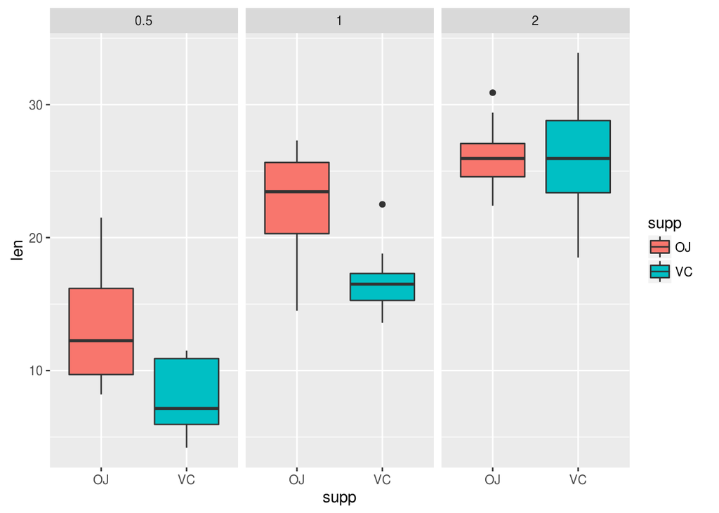

```r
ggplot(data = ToothGrowth, aes(x = supp, y = len)) +
         geom_boxplot(aes(fill = supp)) + facet_wrap(~ dose)
```

#### **3. Use confidence intervals and/or hypothesis tests to compare tooth growth by supp and dose.**

The T-test by dose:

```r
t.test(ToothGrowth$len[ToothGrowth$dose == 1], ToothGrowth$len[ToothGrowth$dose == 0.5],
       paired = FALSE, alternative = "greater")$p.value
```

```
## [1] 6.341504e-08
```

```r
t.test(ToothGrowth$len[ToothGrowth$dose == 2], ToothGrowth$len[ToothGrowth$dose == 1],
       paired = FALSE, alternative = "greater")$p.value
```

```
## [1] 9.532148e-06
```

Note: Increaseng doseages increase mean tooth length.

The T-test by supp:

```r
t.test(len ~ supp, data = ToothGrowth, paired = FALSE)$p.value
```

```
## [1] 0.06063451
```

Note: The p-value of OJ vs. VC is 0.06, which is greater than 0.05, so I accept the null hypothesis. but…

The T-test by supp for each dose:

```r
t.test(len ~ supp, ToothGrowth[ToothGrowth$dose == 0.5, ], paired = FALSE)$p.value
```

```
## [1] 0.006358607
```

```r
t.test(len ~ supp, ToothGrowth[ToothGrowth$dose == 1, ], paired = FALSE)$p.value
```

```
## [1] 0.001038376
```

```r
t.test(len ~ supp, ToothGrowth[ToothGrowth$dose == 2, ], paired = FALSE)$p.value
```

```
## [1] 0.9638516
```

Note:

In case of doseages is **0.5**, the p-value of OJ vs. VC is 0.006, which is less than 0.05, so I **DO NOT** accept the null hypothesis.

In case of doseages is **1.0**, the p-value of OJ vs. VC is 0.001, which is less than 0.05, so I **DO NOT** accept the null hypothesis.

In case of doseages is **2.0**, the p-value of OJ vs. VC is 0.964, which is greater than 0.05, so I accept the null hypothesis.

#### **4. State your conclusions and the assumptions needed for your conclusions.**

- Increaseng doseages increase mean tooth length.
- Orange juice (OJ) increase tooth length unless doseage is 2.0.